# Homework 2 - Priors and Data

Courtney Hodge

2024-10-07

```r
library(tidyverse)
wine <- read.csv("C:\\Users\\hodge\\Downloads\\whitewine-training-ds6040.csv")
```

# Part 1: Using Conjugate Priors with White-Wine Data (33pts)

- Choose 2 continuous predictors and plot density plots (using ggplot2)

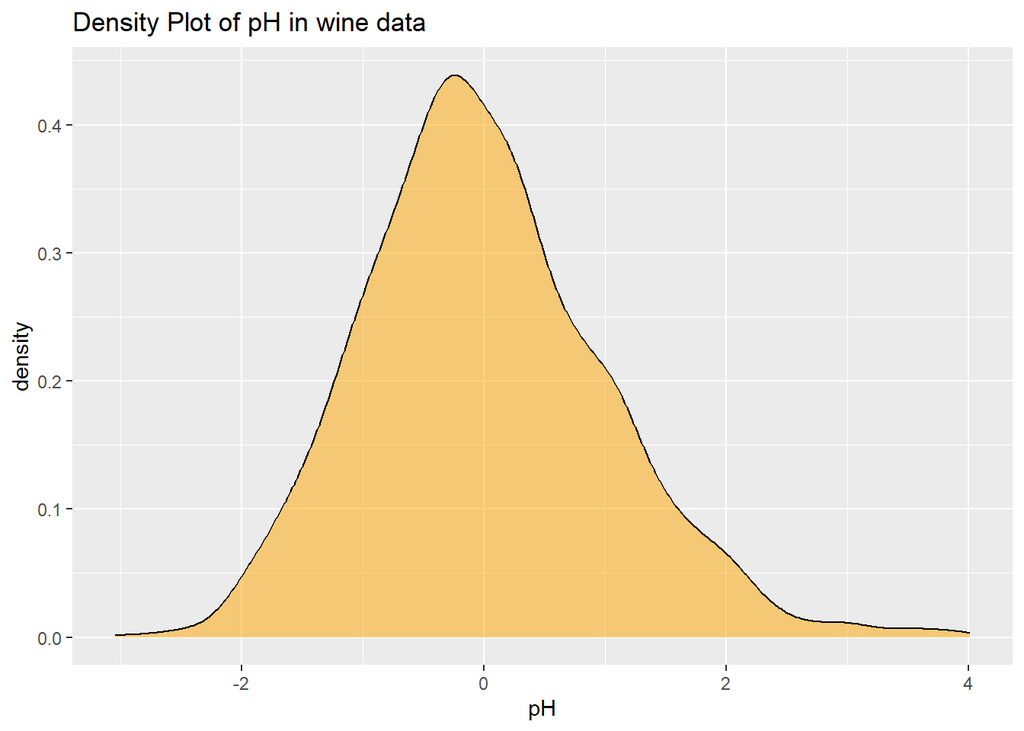

```r
library(ggplot2)

ggplot(wine, aes(x = pH)) +
  geom_density(fill = "orange", alpha = 0.5) +
  ggtitle(paste("Density Plot of pH in wine data" ))
```

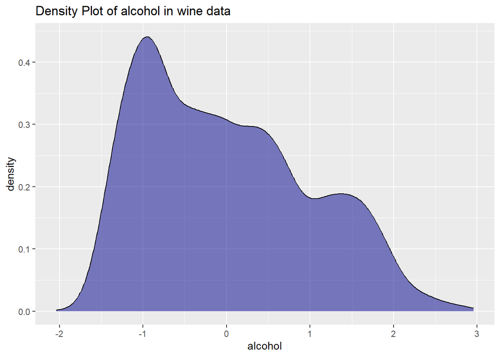

```r
ggplot(wine, aes(x = alcohol)) +
  geom_density(fill = "darkblue", alpha = 0.5) +
  ggtitle(paste("Density Plot of alcohol in wine data"))
```

- For each predictor, consider the density plot. What do you notice? Do they look like they are normally distributed? Skewed?

> For the pH predictor, the denisty plot looks similar to a normal distribution centered around 0 pH with an extremely slight skew right, which is not bad at all. There’s also symetry with this distribution. For the alcohol predictor, there is not a normal distrbution of this data. If anything, it is very strongly skewed right, with a peak around -1.

## Now, for each variable please do the following:

### 1.

Using a normal likelihood with known variance (the known variance for each variable is the observed variance, go ahead and calculate that),

use the appropriate conjugate prior and calculate out the posterior distribution (you should be able to look up the formula for the posteriors, no need to derive them out yourself). When you calculate these posterior distributions, use two sets of hyperparameters (per variable), one where the hyperparameters specify a fairly uninformative prior, and the other where the hyperparameters are much more informative (this doesn’t need to be a reasonable value either, this exercise is to demonstrate the impact of hyperparameter choice). At the end of this exercise, you should have the parameters for 4 posterior distributions.

```r
# Split data into pH and alcohol
pH_data <- wine[c(9)] # pH column
alcohol_data <- wine[c(10)] # alcohol column

#Number of samples
n_pH <- length(pH_data) #pH column
n_alcohol <- length(alcohol_data) #alcohol column

#uninformative prior parameters for both pH and alcohol
mu_0_uninform <- 0
tau_0_uninform <- 1000 #large variance

#known variance (since data is standardized)
sigma_sq <- 1

#sample means (standardized data has mean close to 0)
x_bar_pH <- 0
x_bar_alcohol <- 0

#----
#Uninformative Priors

#posterior calculations for uninformative prior
mu_post_uninform <- function(n, sigma_sq, x_bar, mu_0, tau_0_sq) {
  ( (n / sigma_sq) * x_bar + (1 / tau_0_sq) * mu_0 ) / ( (n / sigma_sq) + (1 / tau_0_sq) )
}

tau_post_uninform <- function(n, sigma_sq, tau_0_sq) {
  1 / ( (n / sigma_sq) + (1 / tau_0_sq) )
}

# posterior for pH (uninformative prior)
mu_post_pH_uninform <- mu_post_uninform(n_pH, sigma_sq, x_bar_pH, mu_0_uninform, tau_0_uninform)

tau_post_pH_uninform <- tau_post_uninform(n_pH, sigma_sq, tau_0_uninform)

# Posterior for alcohol (uninformative prior)
mu_post_alcohol_uninform <- mu_post_uninform(n_alcohol, sigma_sq, x_bar_alcohol, mu_0_uninform, tau_0_uninform)

tau_post_alcohol_uninform <- tau_post_uninform(n_alcohol, sigma_sq, tau_0_uninform)


mu_post_pH_uninform
```

```
## [1] 0
```

```r
tau_post_pH_uninform
```

```
## [1] 0.999001
```

```r
mu_post_alcohol_uninform
```

```
## [1] 0
```

```r
tau_post_alcohol_uninform
```

```
## [1] 0.999001
```

```r
#Informative Priors
mu_0_pH_inform <- -0.2
tau_0_pH_inform <- 0.01

mu_0_alcohol_inform <- -0.7
tau_0_alcohol_inform <- 0.01

#posterior for pH (informative prior)
mu_post_pH_inform <- mu_post_uninform(n_pH, sigma_sq, x_bar_pH, mu_0_pH_inform, tau_0_pH_inform)

tau_post_pH_inform <- tau_post_uninform(n_pH, sigma_sq, tau_0_pH_inform)

#posterior for alcohol (informative prior)
mu_post_alcohol_inform <- mu_post_uninform(n_alcohol, sigma_sq, x_bar_alcohol, mu_0_alcohol_inform, tau_0_alcohol_inform)

tau_post_alcohol_inform <- tau_post_uninform(n_alcohol, sigma_sq, tau_0_alcohol_inform)

mu_post_pH_inform
```

```
## [1] -0.1980198
```

```r
tau_post_pH_inform
```

```
## [1] 0.00990099
```

```r
mu_post_alcohol_inform
```

```
## [1] -0.6930693
```

```r
tau_post_alcohol_inform
```

```
## [1] 0.00990099
```

### 2.

What are the impacts of different hyperparameter choices on the posterior distributions? Is it possible to chose “bad” hyperparameters? If so, why? What are the consequences for inference?

> The hyperparameter choices do significantly affect the posterior distribution. Informative priors can pull the posterior toward the prior belief, which is great if the prior is accurate, but can lead to bias if it’s not. Uninformative priors let the data dominate, reducing bias but underutilizing prior knowledge.

> It is possible to choose bad hyperparameters. An incorrect mean of a very small variance could cause biased posteriors or overconfident estimates.

> The consequences for inference are incorrect conclusions, misinformed decision, and poor predictions.

## Now, we are going to repeat the process, but this time using a different likelihood function.

### 1.

Repeat the previous work, but this time use an exponential likelihood and corresponding conjugate prior (again, you can look this up and get the formula that way).

```r
#Taking absolute values (since exponential distribution assumes positive values)
pH_data <- abs(pH_data)
alcohol_data <- abs(alcohol_data)

#Sums of the data
sum_pH <- sum(pH_data)
sum_alcohol <- sum(alcohol_data)

#uninformative Prior
alpha_uninform <- 1
beta_uninform <- 1

#informative prior
alpha_inform <- 5
beta_inform <- 0.5

#sums of the data (since exponential assumes non-negative values, we use asbolute values)
sum_pH <- sum(pH_data)
sum_alcohol <- sum(alcohol_data)

#posterior calculations for uninformative prior
alpha_post_pH_uninform <- alpha_uninform + n_alcohol

beta_post_pH_uninform <- beta_uninform + sum_pH

alpha_post_alcohol_uninform <- alpha_uninform + n_alcohol
beta_post_alcohol_uninform <- beta_uninform + sum_alcohol

cat("Posterior for pH (Uninformative Prior): Alpha =", alpha_post_pH_uninform, ", Beta =", beta_post_pH_uninform, "\n\n")
```

```
## Posterior for pH (Uninformative Prior): Alpha = 2 , Beta = 2489.002
```

```r
cat("Posterior for Alcohol (Uninformative Prior): Alpha =", alpha_post_alcohol_uninform, ", Beta =", beta_post_alcohol_uninform, "\n")
```

```
## Posterior for Alcohol (Uninformative Prior): Alpha = 2 , Beta = 2444.307
```

```r
#informative prior
# Posterior calculations for informative prior
alpha_post_pH_inform <- alpha_inform + n_pH
beta_post_pH_inform <- beta_inform + sum_pH

alpha_post_alcohol_inform <- alpha_inform + n_alcohol
beta_post_alcohol_inform <- beta_inform + sum_alcohol

cat("Posterior for pH (Informative Prior): Alpha =", alpha_post_pH_inform, ", Beta =", beta_post_pH_inform, "\n\n")
```

```
## Posterior for pH (Informative Prior): Alpha = 6 , Beta = 2488.502
```

```r
cat("Posterior for Alcohol (Informative Prior): Alpha =", alpha_post_alcohol_inform, ", Beta =", beta_post_alcohol_inform, "\n")
```

```
## Posterior for Alcohol (Informative Prior): Alpha = 6 , Beta = 2443.807
```

### 2.

Again, what are the impacts of the hyperparameter choice?

### 3.

In the previous example, it was very simple for you to interpret the parameters in the posteriors. In this case, you will need to calculate the expected value and variance of the posterior distribution. You can look this up for the distribution (use Wikipedia!). How do these values differ from the values you found when using a normal distribution as the likelihood?

```r
#calculating the expected value and variance for the Gamma posterior

#pH (uninformative prior)
expected_pH_uninform <- alpha_post_pH_uninform / beta_post_pH_uninform

variance_pH_uninform <- alpha_post_pH_uninform / (beta_post_pH_uninform ^ 2)

#alcohol (uninformative prior)
expected_alcohol_uninform <- alpha_post_alcohol_uninform / beta_post_alcohol_uninform

variance_alcohol_uninform <- alpha_post_alcohol_uninform / (beta_post_alcohol_uninform ^2)

# Print the results
cat("Uninformative Prior Results:\n")
```

```
## Uninformative Prior Results:
```

```r
cat("Expected value for pH:", expected_pH_uninform, "\n")
```

```
## Expected value for pH: 0.0008035348
```

```r
cat("Variance for pH:", variance_pH_uninform, "\n\n")
```

```
## Variance for pH: 3.228341e-07
```

```r
cat("Expected value for alcohol:", expected_alcohol_uninform, "\n")
```

```
## Expected value for alcohol: 0.0008182277
```

```r
cat("Variance for alcohol:", variance_alcohol_uninform, "\n\n")
```

```
## Variance for alcohol: 3.347483e-07
```

```r
# For pH (informative prior)
expected_pH_inform <- alpha_post_pH_inform / beta_post_pH_inform
variance_pH_inform <- alpha_post_pH_inform / (beta_post_pH_inform^2)

# For alcohol (informative prior)
expected_alcohol_inform <- alpha_post_alcohol_inform / beta_post_alcohol_inform
variance_alcohol_inform <- alpha_post_alcohol_inform / (beta_post_alcohol_inform^2)

cat("Informative Prior Results:\n")
```

```
## Informative Prior Results:
```

```r
cat("Expected value for pH:", expected_pH_inform, "\n")
```

```
## Expected value for pH: 0.002411089
```

```r
cat("Variance for pH:", variance_pH_inform, "\n\n")
```

```
## Variance for pH: 9.688914e-07
```

```r
cat("Expected value for alcohol:", expected_alcohol_inform, "\n")
```

```
## Expected value for alcohol: 0.002455185
```

```r
cat("Variance for alcohol:", variance_alcohol_inform, "\n")
```

```
## Variance for alcohol: 1.004656e-06
```

> The key difference is that in the exponential likelihood case, the posterior distrbution is skewed and depends on the sum of the data. On the other hand, the normal likelihood posterior is symmetric and centered around the mean of the data.

# Part 2: Multinominal Priors for Wine Quality (33 points)

The quality variable in this dataset is a categorical variable with values taking letter grades (A, C, F). We can consider this variable to be multinomially distributed. Multinomial distributions have a conjugate prior in the Dirichlet distribution. The Dirichlet distribution can be parameterized using either a single α parameter that applies to each category, or you can specify a different αk parameter for each category. In any case, the posterior distribution for a multinomial-Dirichlet model is Dirichlet(α + n) , where α is a vector of either all the same number, or the hyperparameter choice per category, and n is a vector of the counts of each category.

### 1.

Looking at the above formula for the posterior distribution, how can you interpret the meaning of α?

> We can interpret the meaning of alpha as the affect of how much weight our prior beliefs have compared to the observed data.

> If we have multiple categories, like A, C, and F, larger values for alpha will indicate stronger confidence, in our prior beleif, meaning the data will have less impact on the posterior distribution.

> If we have smaller values for alpha, this means we have a weaker prior, allowing for observed data to have a larger impact on shaping the posterior.

> Lastly, if all elements of alpha are equal, this implies an assumption of equal likelihood for each category in the prior.

### 2.

Choosing two sets of hyperparameters, one fairly uninformative and one highly informative, generate 1000 observations from the posterior distributions (using rdirichlet from the dirmult R package). At the end of this generative process, you should have two data.frames or matrices that have 1000 rows and 3 columns.

```r
#load library
library(dirmult)

#two sets of hyperparameters
#one fairly uninformative
alpha_uninform <- c(1,1,1)

#one highly informative
alpha_inform <- c(10, 50, 40)

#generate 1000 samples from Dirichlet posterior
set.seed(123)
samples_uninform <- rdirichlet(1000, alpha_uninform)

samples_inform <- rdirichlet(1000, alpha_inform)

#convert to data.frames
df_uninform <- as.data.frame(samples_uninform)
df_inform <- as.data.frame(samples_inform)

#view the first few rows
head(df_uninform)
```

```
##           V1         V2        V3
## 1 0.08494729 0.50389049 0.4111622
## 2 0.31242697 0.53955008 0.1480229
## 3 0.42512978 0.38701947 0.1878507
## 4 0.74937269 0.07719163 0.1734357
## 5 0.21065883 0.46413171 0.3252095
## 6 0.49430280 0.29666493 0.2090323
```

```r
head(df_inform)
```

```
##           V1        V2        V3
## 1 0.12764602 0.4015625 0.4707915
## 2 0.12237055 0.5005114 0.3771180
## 3 0.07992684 0.4837090 0.4363641
## 4 0.10771561 0.4933435 0.3989409
## 5 0.13160899 0.4320157 0.4363753
## 6 0.07889257 0.4257316 0.4953759
```

### 3.

Plot these posterior distributions (you should end up with 2 figures of box plots, one figure per prior specification, each figure containing 3 boxplots, one for each letter grade).

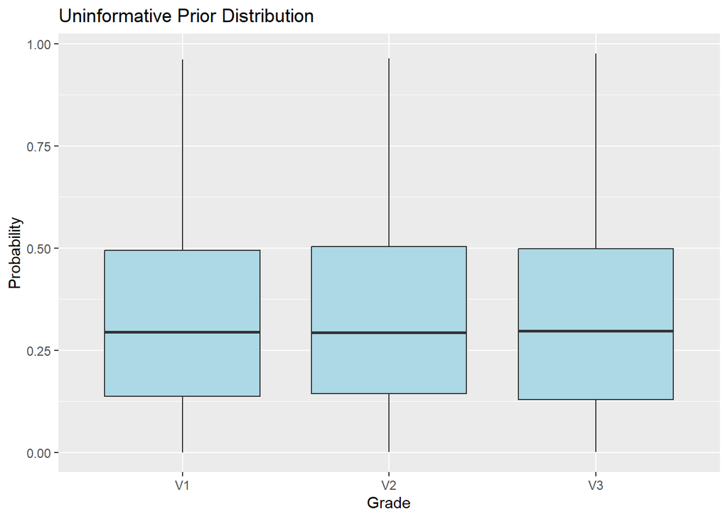

```r
library(ggplot2)

# Reshape data to long format for easier plotting
df_uninformative_long <- reshape2::melt(df_uninform, variable.name = "Grade", value.name = "Probability")
df_informative_long <- reshape2::melt(df_inform, variable.name = "Grade", value.name = "Probability")
#boxplot for uninformative prior
p1 <- ggplot(df_uninformative_long, aes(x = Grade, y = Probability)) +
  geom_boxplot(fill = "lightblue") +
  ggtitle("Uninformative Prior Distribution")

p2 <- ggplot(df_informative_long, aes(x = Grade, y = Probability)) +
  geom_boxplot(fill = 'lightgreen')+
  ggtitle("Informative Prior Distribution")

p1
```

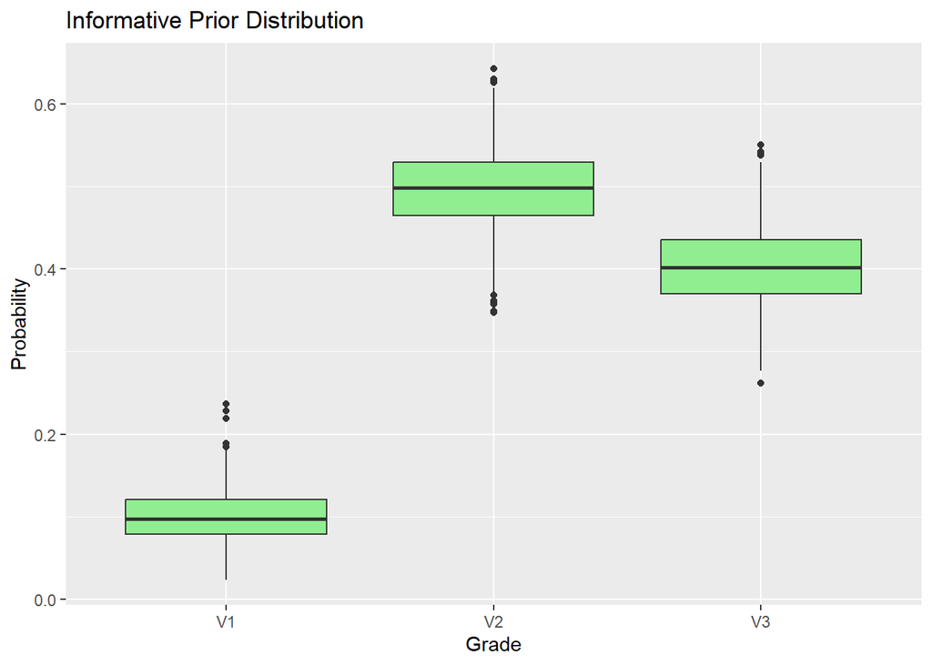

```r
p2
```

### 4.

Comment on the impact of prior choice here.

# Part 3: A Bayesian Test of Inference (34 points)

What we’ve been doing so far here is exploring the impact of priors using marginal distributions. While you could technically do some form of statistical inference with these, the inference isn’t that interesting (is alcohol significantly different from 0? for example). In this part, we are going to be using conjugate priors to examine the difference in alcohol content between wines rated A and wines rated F

To do this, follow these steps:

### 1.

Using a normal distribution with known variance (again, using the variances you can calculate from the data), specify 2 hyperparameter choices, one fairly uninformative, one very informative, for the alcohol content in wines rated A and wines rated F. Note, you will need hyperparameters for each type of wine, but those hyperparameters can be the same for each type of wine.

```r
#filter the data by wine rating
wine_A <- wine[wine$wine_quality == "A", ]
wine_F <- wine[wine$wine_quality == "F", ]

#extract alcohol content wines rated A and F
alcohol_A <- wine_A$alcohol
alcohol_F <- wine_F$alcohol

#number of samples
n_A <- length(alcohol_A)
n_F <- length(alcohol_F)

#sample menas
x_bar_A <- mean(alcohol_A)
x_bar_F <- mean(alcohol_F)

#sample variances
var_A <- var(alcohol_A)
var_F <- var(alcohol_F)

#Uninformative prior hyperparameters (same for both A and F)
mu_0_uninform <- 0
tau_0_uninform <- 1000

#informative prior hyperparameters
mu_0_inform <- 0.5
tau_0_inform <- 0.1

#Posterior mean and variance calculation functions
mu_post <- function(n, sigma_sq, x_bar, mu_0, tau_0_sq) {
  ( (n / sigma_sq) * x_bar + (1 / tau_0_sq) * mu_0 ) / ( (n / sigma_sq) + (1 / tau_0_sq) )
}

tau_post <- function(n, sigma_sq, tau_0_sq) {
  1 / ( (n / sigma_sq) + (1 / tau_0_sq) )
}
```

### 2.

Calculate out the posterior distributions for alcohol content in wines with an F rating, and wines with an A rating. Because the posterior distribution will be a normal distribution with a value for the posterior mean and variance, you will have two means and two variances (per hyperparameter set, so you’ll have 4 in total.)

```r
#known variance (we use the sample variance as the known variance)
sigma_sq_A <- var_A
sigma_sq_F <- var_F

#posterior for wines rated A (uninformative prior)
mu_post_A_uninform <- mu_post(n_A, sigma_sq_A, x_bar_A, mu_0_uninform, tau_0_uninform)

tau_post_A_uninform <- tau_post(n_A, sigma_sq_A, tau_0_uninform)

# Posterior for wines rated F (Uninformative Prior)
mu_post_F_uninform <- mu_post(n_F, sigma_sq_F, x_bar_F, mu_0_uninform, tau_0_uninform)

tau_post_F_uninform <- tau_post(n_F, sigma_sq_F, tau_0_uninform)

# Posterior for wines rated A (Informative Prior)
mu_post_A_inform <- mu_post(n_A, sigma_sq_A, x_bar_A, mu_0_inform, tau_0_inform)

tau_post_A_inform <- tau_post(n_A, sigma_sq_A, tau_0_inform)

# Posterior for wines rated F (Informative Prior)
mu_post_F_inform <- mu_post(n_F, sigma_sq_F, x_bar_F, mu_0_inform, tau_0_inform)

tau_post_F_inform <- tau_post(n_F, sigma_sq_F, tau_0_inform)

# Print posterior results
cat("Uninformative Prior (A): Mean =", mu_post_A_uninform, "Variance =", tau_post_A_uninform, "\n\n")
```

```
## Uninformative Prior (A): Mean = 0.903638 Variance = 0.0108299
```

```r
cat("Uninformative Prior (F): Mean =", mu_post_F_uninform, "Variance =", tau_post_F_uninform, "\n\n")
```

```
## Uninformative Prior (F): Mean = -0.5594685 Variance = 0.0005206296
```

```r
cat("Informative Prior (A): Mean =", mu_post_A_inform, "Variance =", tau_post_A_inform, "\n\n")
```

```
## Informative Prior (A): Mean = 0.8642044 Variance = 0.009771737
```

```r
cat("Informative Prior (F): Mean =", mu_post_F_inform, "Variance =", tau_post_F_inform, "\n\n")
```

```
## Informative Prior (F): Mean = -0.5539814 Variance = 0.0005179334
```

### 3.

These posterior distributions are still for the marginal distributions of alcohol content, and we are interested in if the alcohol content differs between the two levels of wine quality. Fortunately, the difference between normal distributions is a normal distribution, so we can hand calculate the posterior distribution of the differences between alcohol content:

#### 1.

The posterior mean of the difference between two normal distributions with means μx and μy is simply μx − μy

```r
#uninformative prior: posterior difference in means
mu_diff_uninform <- mu_post_A_uninform - mu_post_F_uninform

#informative prior: posterior difference in means
mu_diff_inform <- mu_post_A_inform - mu_post_F_inform

# Print posterior means
cat("Posterior Mean Difference (Uninformative Prior):", mu_diff_uninform, "\n\n")
```

```
## Posterior Mean Difference (Uninformative Prior): 1.463107
```

```r
cat("Posterior Mean Difference (Informative Prior):", mu_diff_inform, "\n\n")
```

```
## Posterior Mean Difference (Informative Prior): 1.418186
```

#### 2.

The posterior variance of the difference between two normal distributions (with variances σ2 x and σ2 y ) is simply σ2 x + σ2 y.

```r
#uninformative prior: posterior difference in means and variances
tau_diff_uninform <- tau_post_A_uninform + tau_post_F_uninform

#informative prior: posterior difference in variances
tau_diff_inform <- tau_post_A_inform + tau_post_F_inform


# Print posterior variances
cat("Posterior Variance Difference (Uninformative Prior):", tau_diff_uninform, "\n\n")
```

```
## Posterior Variance Difference (Uninformative Prior): 0.01135053
```

```r
cat("Posterior Variance Difference (Informative Prior):", tau_diff_inform, "\n")
```

```
## Posterior Variance Difference (Informative Prior): 0.01028967
```

### 4.

Now, you should have the posterior distributions of the differences between alcohol contents for wines rated A vs F. You’ll have 2 of these posterior distributions because you had two sets of priors, one uninformative, one highly informative.

#### 1.

Calculate the 95% HDI for each of the posterior distributions. What does this interval tell you about the difference between the alcohol quantities in the two grades of wine? Would you consider the alcohol content to be ‘significantly’ different?

```r
# Function to calculate 95% HDI for a normal distribution
hdi_95 <- function(mu, tau) {
  lower_bound <- mu - 1.96 * sqrt(tau)
  upper_bound <- mu + 1.96 * sqrt(tau)
  return(c(lower_bound, upper_bound))
}

#95% HDI for Uninformative Prior
hdi_uninform <- hdi_95(mu_diff_uninform, tau_diff_uninform)

#95% HDI for Informative Prior
hdi_inform <- hdi_95(mu_diff_inform, tau_diff_inform)

# Print the 95% HDI for both priors
cat("95% HDI (Uninformative Prior):", hdi_uninform, "\n\n")
```

```
## 95% HDI (Uninformative Prior): 1.25429 1.671923
```

```r
cat("95% HDI (Informative Prior):", hdi_inform, "\n")
```

```
## 95% HDI (Informative Prior): 1.219367 1.617004
```

#### 2.

How does prior choice impact this?

> With an uninformative prior, the posterior distribution will rely more on the data and provide a more flexible HDI. The interval may be wider because of the high variance in the prior. This will lead to more uncertainty.

> With an informative prior, if the informative prior has a small variance, the HDI will likely be narrower. This could lead to overconfidence in the prior if it does not match the actual data.

# Extra Credit (25 pts)

Savvy students will notice I made an important assumption in specifying the likelihoods in part 1 and 2, that they are normal likelihoods with known variance. This was to simplify the posterior from a normal-inverse-gamma to just a normal distribution. However, technically, it’s a bad assumption to make. In this extra credit, you will be writing a small Stan analysis to test the difference between alcohol quantities in wines rated A and wines rated F, when we don’t assume we know the variance of the alcohol quantities.

### 1.

Write a Stan model that specifies normal-likelihoods with unknown means and variances. The priors for the means should be normal distributions, while the priors for variances should be a Half-Cauchy (note, this is not the conjugate prior, but we are going to be using Stan here, so we don’t need to chose conjugate priors!). Then, using the transformed parameters block, calculate the difference between the means of the marginal distributions.

```r
library(rstan)
# Define the Stan model as a string
stan_model_code <- "
data {
    int<lower=0> N_A;         // Number of observations for wine rating A
    int<lower=0> N_F;         // Number of observations for wine rating F
    vector[N_A] alcohol_A;    // Alcohol quantities for wine rating A
    vector[N_F] alcohol_F;    // Alcohol quantities for wine rating F
}

parameters {
    real mu_A;                    // Mean alcohol quantity for wine rating A
    real mu_F;                    // Mean alcohol quantity for wine rating F
    real<lower=0> sigma_A;        // Standard deviation for alcohol in wine rating A
    real<lower=0> sigma_F;        // Standard deviation for alcohol in wine rating F
}

transformed parameters {
    real mean_diff;               // Difference between means of alcohol quantities
    mean_diff = mu_A - mu_F;      // Difference between wine rating A and F
}

model {
    // Priors for means: Normal distributions
    mu_A ~ normal(0, 10);         // Prior for the mean of alcohol A
    mu_F ~ normal(0, 10);         // Prior for the mean of alcohol F

    // Priors for standard deviations: Half-Cauchy distributions
    sigma_A ~ cauchy(0, 5);       // Half-Cauchy prior for the standard deviation of alcohol A
    sigma_F ~ cauchy(0, 5);       // Half-Cauchy prior for the standard deviation of alcohol F

    // Likelihood: Normal distributions for alcohol quantities
    alcohol_A ~ normal(mu_A, sigma_A);
    alcohol_F ~ normal(mu_F, sigma_F);
}

generated quantities {
    real<lower=0> var_A;          // Variance for wine rating A
    real<lower=0> var_F;          // Variance for wine rating F

    var_A = sigma_A^2;
    var_F = sigma_F^2;
}
"
```

### 2.

```r
set.seed(42)

# Create a list for Stan's input
stan_data <- list(
    N_A = length(alcohol_A),
    N_F = length(alcohol_F),
    alcohol_A = alcohol_A,
    alcohol_F = alcohol_F
)
```

```r
# Compile the Stan model
stan_model <- stan_model(model_code = stan_model_code)

# Fit the model using MCMC sampling
fit <- sampling(stan_model, data = stan_data, iter = 2000, chains = 4, seed = 123)
# Print a summary of the results
print(fit, pars = c("mu_A", "mu_F", "mean_diff", "sigma_A", "sigma_F", "var_A", "var_F"))
```

```
## Inference for Stan model: anon_model.
## 4 chains, each with iter=2000; warmup=1000; thin=1;
## post-warmup draws per chain=1000, total post-warmup draws=4000.
##
##            mean se_mean   sd  2.5%   25%   50%   75% 97.5% n_eff Rhat
## mu_A       0.90       0 0.11  0.69  0.83  0.90  0.97  1.11  4412    1
## mu_F      -0.56       0 0.02 -0.60 -0.57 -0.56 -0.54 -0.51  4282    1
## mean_diff  1.46       0 0.11  1.25  1.39  1.46  1.53  1.67  4329    1
## sigma_A    1.05       0 0.07  0.92  1.00  1.05  1.10  1.20  3966    1
## sigma_F    0.72       0 0.02  0.69  0.71  0.72  0.73  0.75  4871    1
## var_A      1.11       0 0.15  0.85  1.00  1.10  1.21  1.44  3900    1
## var_F      0.52       0 0.02  0.48  0.51  0.52  0.54  0.57  4858    1
##
## Samples were drawn using NUTS(diag_e) at Wed Oct 16 10:41:04 2024.
## For each parameter, n_eff is a crude measure of effective sample size,
## and Rhat is the potential scale reduction factor on split chains (at
## convergence, Rhat=1).
```

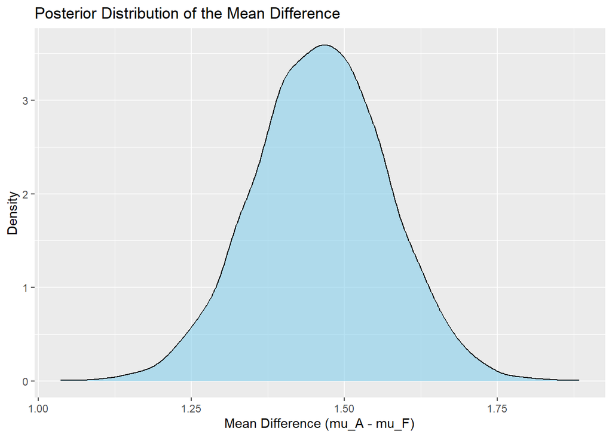

```r
library(ggplot2)

# Extract posterior samples
posterior_samples <- extract(fit)

# Plot the posterior distribution of the mean difference
mean_diff_samples <- posterior_samples$mean_diff
ggplot(data.frame(mean_diff = mean_diff_samples), aes(x = mean_diff)) +
  geom_density(fill = "skyblue", alpha = 0.6) +
  labs(title = "Posterior Distribution of the Mean Difference",
       x = "Mean Difference (mu_A - mu_F)",
       y = "Density")
```

### 3.

How are these posteriors different/similar to those from the original analyses where we specified the variances as known? What was the impact of priors here?

> This current analysis also shows that the variances are estimated from the data, leading to additional uncertainty that wasn’t present in the original analysis.